# Climate Change Analysis

To study climate change, I used the data on the *Combined Land-Surface Air and Sea-Surface Water Temperature Anomalies* in the Northern Hemisphere from [NASA’s Goddard Institute for Space Studies](https://data.giss.nasa.gov/gistemp).

The [tabular data of temperature anomalies can be found here](https://data.giss.nasa.gov/gistemp/tabledata_v4/NH.Ts+dSST.txt)

As a base period to define anomalies, I use the period between 1951-1980.

Let’s load the file:

```r
weather <-
  read_csv("https://data.giss.nasa.gov/gistemp/tabledata_v4/NH.Ts+dSST.csv",
           skip = 1,
           na = "***")
```

You have two objectives in this section:

1. Select the year and the twelve month variables from the `weather` dataset. We do not need the others (J-D, D-N, DJF, etc.) for this assignment. Hint: use `select()` function.
2. Convert the dataframe from wide to ‘long’ format. Hint: use `gather()` or `pivot_longer()` function. Name the new dataframe as `tidyweather`, name the variable containing the name of the month as `month`, and the temperature deviation values as `delta`.

I’m pivoting the weather data to long format for easier anlaysis.

```r
tidyweather <- weather %>%
               select(1:13) %>%
               pivot_longer(!Year, names_to = "Month", values_to = "delta")
```

Next, I’ll the data using a time-series scatter plot, and add a trend line.

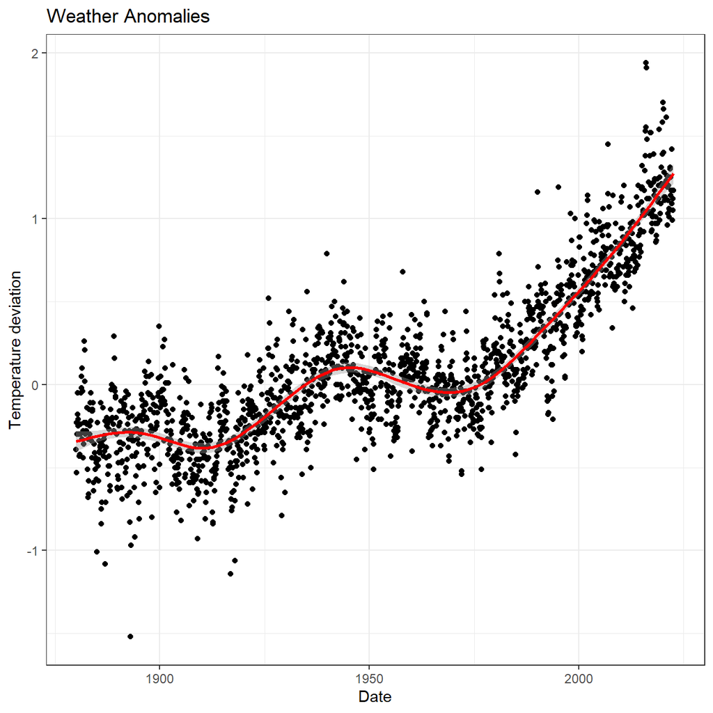

```r
tidyweather <- tidyweather %>%
  mutate(date = ymd(paste(as.character(Year), Month, "1")),
         month = month(date, label=TRUE),
         year = year(date))

ggplot(tidyweather, aes(x=date, y = delta))+
  geom_point()+
  geom_smooth(color="red") +
  theme_bw() +
  labs (
    x = "Date",
    y = "Temperature deviation",
    title = "Weather Anomalies",
  )
```

It is sometimes useful to group data into different time periods to study historical data. For example, we often refer to decades such as 1970s, 1980s, 1990s etc. to refer to a period of time. NASA calcuialtes a temperature anomaly, as difference form the base periof of 1951-1980. The code below creates a new data frame called `comparison` that groups data in five time periods: 1881-1920, 1921-1950, 1951-1980, 1981-2010 and 2011-present.

```r
comparison <- tidyweather %>%
  filter(Year>= 1881) %>%     #remove years prior to 1881
  #create new variable 'interval', and assign values based on criteria below:
  mutate(interval = case_when(
    Year %in% c(1881:1920) ~ "1881-1920",
    Year %in% c(1921:1950) ~ "1921-1950",
    Year %in% c(1951:1980) ~ "1951-1980",
    Year %in% c(1981:2010) ~ "1981-2010",
    TRUE ~ "2011-present"
  ))
```

I’ll now create a density plot to study the distribution of monthly deviations (`delta`), grouped by the different time periods.

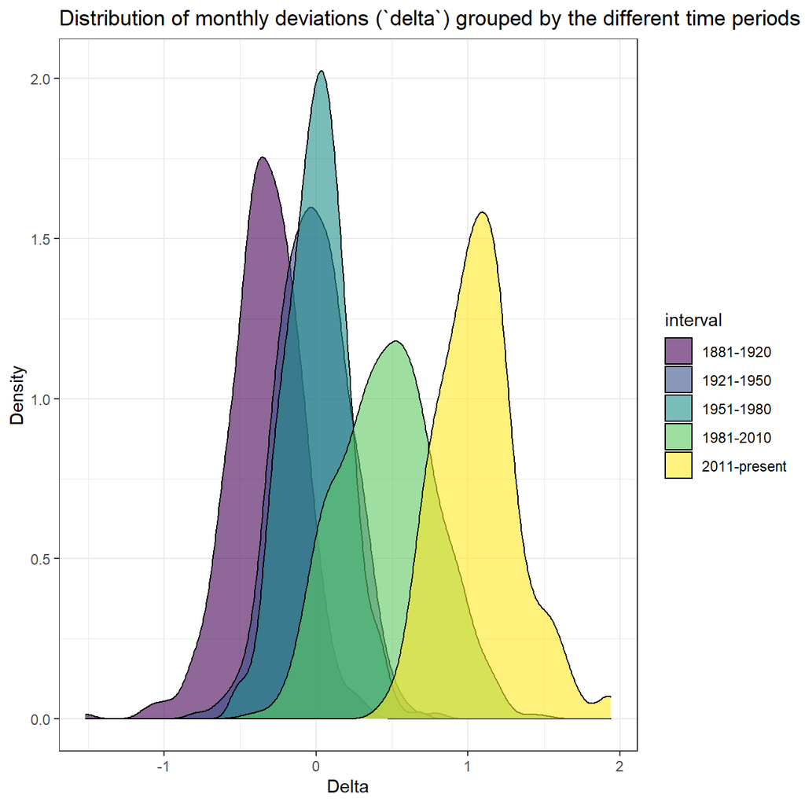

```r
library(viridis)
ggplot(comparison, aes(x = delta, fill = interval)) +
  geom_density(alpha=.6) +
 # theme(legend.position="none") +
  theme_bw()+
  scale_fill_viridis(discrete = TRUE, option = "D") +
  labs(x = "Delta",
       y = "Density",
       title = "Distribution of monthly deviations (`delta`) grouped by the different time periods")
```

Let’s take a peek at average annual anomalies next:

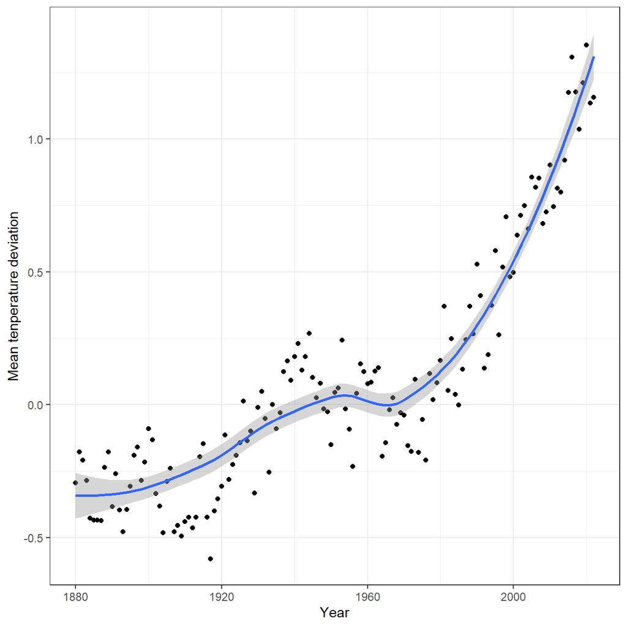

```r
#creating yearly averages
average_annual_anomaly <- tidyweather %>%
  group_by(Year) %>%   #grouping data by Year

  # creating summaries for mean delta
  # use `na.rm=TRUE` to eliminate NA (not available) values
  summarise(mean_delta = mean(delta, na.rm = TRUE))

#plotting the data:
ggplot(average_annual_anomaly, aes(x = Year, y = mean_delta)) +
  geom_point() +
  #Fit the best fit line, using LOESS method
  geom_smooth(method = loess) +
  #change theme to theme_bw() to have white background + black frame around plot
  theme_bw() +
  labs(x = "Year",
       y = "Mean tenperature deviation")
```